# Trumpet Report

# 1 Introduction to Trumpet

MeRIP-seq can be considered as a marriage of ChIP-seq and RNA-seq, which is an enrichment-based approach that profiles the transcriptome-wide distribution of RNA modifications.

In MeRIP-seq, as in all other NGS applications, quality control is essential. However, to our knowledge, no metrics or software can be used to assess the MeRIP-seq experiment data recently. Thus, we developed an R package that come up with some metrics to assess the MeRIP-seq data quality easily. `Trumpet`, the R package for quality assessment of MeRIP-seq data, can also visualize the assessment result in HTML format.

The quality of m6A-seq data is mainly assessed from mainly 3 perspectives by `Trumpet`, including (1) statistics of sequencing reads distribution with respect to different genomic regions; (2) the strength of immunoprecipitation signal evaluated by statistical approaches; (3) comparison between different biological replicates and identification of possible outliers.

# 2 Start using Trumpet

## 2.1 Input data for quality assessment

The MeRIP-seq data for quality assessment should include the IP, Input samples(single condition) or IP, Input and contrast IP, contrast Input samples(different conditions). These samples should be BAM format files with alignment reads. Users also need to provide the transcriptome annotation file with a GTF file, a TxDb object or download this information from UCSC automatically.

## 2.2 Get reads count from input samples

The following part will extract the reads count from input samples for subsequent quality assessment. It must import the paths of input sample data paths(e.g. the location of `IP_BAM, Input_BAM`) and the location of the transcriptome annotation file like gtf or txdb object.

```
## [1] "total 63 transcripts extracted ..."
## [1] "total 36 transcripts left after ambiguity filter ..."
## [1] "total 21 mRNAs left after component length filter ..."
## [1] "total 5 ncRNAs left after ncRNA length filter ..."
## [1] "Building Guitar Coordinates. It may take a few minutes ..."
## [1] "Guitar Coordinates Built ..."
## [1] "working on the 1-th bam file ..."
## [1] "working on the 2-th bam file ..."
## [1] "working on the 3-th bam file ..."
## [1] "working on the 4-th bam file ..."
## [1] "working on the 5-th bam file ..."
## [1] "working on the 6-th bam file ..."
## [1] "working on the 7-th bam file ..."
## [1] "working on the 8-th bam file ..."
## [1] "working on the 9-th bam file ..."
```

# 3 Basic quality assessment module

## 3.1 Statistics of sequencing reads and heterogeneity of reads coverage

In this section, we mainly evaluate reads alignment and their distribution, with which, we can inspect the sequencing depth of the input files, the heterogeneity of reads coverage, the reads alignment mapped to different genomic regions, such as exon, intron, 5’UTR, CDS and 3’UTR. It aims to get global information of samples. The results are shown in the following four tables.

Transform the input files into appropriate labels

| files | sample ID |
| --- | --- |
| /Library/Frameworks/R.framework/Versions/3.4/Resources/library/Trumpet/extdata/IP1.bam | IP1 |
| /Library/Frameworks/R.framework/Versions/3.4/Resources/library/Trumpet/extdata/IP2.bam | IP2 |
| /Library/Frameworks/R.framework/Versions/3.4/Resources/library/Trumpet/extdata/IP3.bam | IP3 |
| /Library/Frameworks/R.framework/Versions/3.4/Resources/library/Trumpet/extdata/IP4.bam | IP4 |
| /Library/Frameworks/R.framework/Versions/3.4/Resources/library/Trumpet/extdata/Input1.bam | Input1 |
| /Library/Frameworks/R.framework/Versions/3.4/Resources/library/Trumpet/extdata/Input2.bam | Input2 |
| /Library/Frameworks/R.framework/Versions/3.4/Resources/library/Trumpet/extdata/Input3.bam | Input3 |
| /Library/Frameworks/R.framework/Versions/3.4/Resources/library/Trumpet/extdata/treated_IP1.bam | Refer_IP1 |
| /Library/Frameworks/R.framework/Versions/3.4/Resources/library/Trumpet/extdata/treated_Input1.bam | Refer_Input1 |

Reads alignment summary

| sample ID | total reads# | exon reads | intron reads | no genic reads | 5’UTR reads | CDS reads | 3’UTR reads |
| --- | --- | --- | --- | --- | --- | --- | --- |
| IP1 | 0M | 0M (48.1%) | 0M (11.91%) | 0M (39.99%) | 0M (9.57%) | 0M (61%) | 0M (29.43%) |
| IP2 | 0M | 0M (45.58%) | 0M (13.64%) | 0M (40.78%) | 0M (12.76%) | 0M (57.2%) | 0M (30.04%) |
| IP3 | 0M | 0M (48.2%) | 0M (9.17%) | 0M (42.63%) | 0M (6.33%) | 0M (58.65%) | 0M (35.02%) |
| IP4 | 0M | 0M (47.53%) | 0M (10.67%) | 0M (41.8%) | 0M (7.35%) | 0M (70.86%) | 0M (21.79%) |
| Input1 | 0M | 0M (47.52%) | 0M (16.85%) | 0M (35.63%) | 0M (13%) | 0M (72.65%) | 0M (14.35%) |
| Input2 | 0M | 0M (40.94%) | 0M (13.52%) | 0M (45.53%) | 0M (8.19%) | 0M (82.77%) | 0M (9.04%) |
| Input3 | 0M | 0M (13.51%) | 0M (32.09%) | 0M (54.4%) | 0M (12.21%) | 0M (48.11%) | 0M (39.68%) |
| Refer_IP1 | 0M | 0M (47.67%) | 0M (13.12%) | 0M (39.2%) | 0M (6.64%) | 0M (62.54%) | 0M (30.82%) |
| Refer_Input1 | 0M | 0M (49.87%) | 0M (10.69%) | 0M (39.44%) | 0M (9.52%) | 0M (80.95%) | 0M (9.53%) |

Exonic regions of different reads coverage

|  | 0 | 1~10 | 10~100 | 100~1000 | 1000~10000 | 10000~100000 |
| --- | --- | --- | --- | --- | --- | --- |
| IP1 | 14.286 % | 0 % | 9.524 % | 33.333 % | 0 % | 0 % |
| IP2 | 23.81 % | 0 % | 0 % | 61.905 % | 0 % | 0 % |
| IP3 | 14.286 % | 9.524 % | 9.524 % | 33.333 % | 0 % | 0 % |
| IP4 | 23.81 % | 0 % | 14.286 % | 38.095 % | 0 % | 0 % |
| Refer_IP1 | 23.81 % | 0 % | 4.762 % | 52.381 % | 0 % | 0 % |
| Input1 | 19.048 % | 4.762 % | 0 % | 66.667 % | 0 % | 0 % |
| Input2 | 23.81 % | 28.571 % | 38.095 % | 0 % | 0 % | 0 % |
| Input3 | 4.762 % | 4.762 % | 80.952 % | 9.524 % | 0 % | 0 % |
| Refer_Input1 | 23.81 % | 14.286 % | 52.381 % | 0 % | 0 % | 0 % |

The percentage of bins with different reads coverage

|  | 0 | 1~10 | 10~100 | 100~1000 | 1000~10000 | 10000~100000 |
| --- | --- | --- | --- | --- | --- | --- |
| IP1 | 33.889 % | 34.683 % | 28.016 % | 3.413 % | 0 % | 0 % |
| IP2 | 35.238 % | 38.016 % | 25.873 % | 0.873 % | 0 % | 0 % |
| IP3 | 39.444 % | 38.254 % | 18.254 % | 4.048 % | 0 % | 0 % |
| IP4 | 41.667 % | 40.635 % | 15.714 % | 1.984 % | 0 % | 0 % |
| Refer_IP1 | 49.365 % | 35 % | 13.81 % | 1.825 % | 0 % | 0 % |
| Input1 | 36.27 % | 34.127 % | 29.206 % | 0.397 % | 0 % | 0 % |
| Input2 | 84.683 % | 14.286 % | 1.032 % | 0 % | 0 % | 0 % |
| Input3 | 57.54 % | 41.905 % | 0.397 % | 0.159 % | 0 % | 0 % |
| Refer_Input1 | 81.19 % | 18.492 % | 0.317 % | 0 % | 0 % | 0 % |

**Note: Column explanation in each table.**

**1. Transform the input files in appropriate labels**

- **file:** The path of input BAM files
- **sample ID:** The ID of input BAM files added automatically

**2. Read alignment summary**

- **total reads#:** Total number of alignment reads in each BAM file
- **exon reads:** Number of reads overlapped into exon regions and the percentage of reads count overlapped into exon regions calculated by $percent\_exon = \frac{exon\_reads^{\#}}{total\_reads^{\#}}$ in each BAM file.
- **intron reads:** Number of reads overlapped into intron regions and the percentage of reads count overlapped into intron regions calculated by $percent\_intron = \frac{intron\_reads^{\#}}{total\_reads^{\#}}$ in each BAM file.
- **nogenic reads:** Number of reads overlapped into non genic regions and the percentage of reads count overlapped into non genic regions calculated by $percent\_nogenic = \frac{nogenic\_reads^{\#}}{total\_reads^{\#}}$ in each BAM file.
- *$intron\_reads^{\#}$*, *$exon\_reads^{\#}$* and *$nogenic\_reads^{\#}$* refers to the number of reads overlapped into intron regions, exon regions and non genic regions respectively.
- **5’UTR reads:** Number of reads overlapped into 5’UTR regions and the percentage of reads count overlapped into 5’UTR regions calculated by $percent\_5'UTR = \frac{5'UTR\_reads^{\#}}{5'UTR\_reads^{\#} + CDS\_reads^{\#} + 3'UTR\_reads^{\#}}$ in each BAM file.
- **CDS reads:** Number of reads overlapped into CDS regions and the percentage of reads count overlapped into CDS regions calculated by $percent\_CDS = \frac{CDS\_reads^{\#}}{5'UTR\_reads^{\#} + CDS\_reads^{\#} + 3'UTR\_reads^{\#}}$ in each BAM file.
- **3’UTR reads** : Number of reads overlaped into 3’UTR regions and the percentage of reads count overlapped into 3’UTR regions calculated by $percent\_3'UTR = \frac{3'UTR\_reads^{\#}}{5'UTR\_reads^{\#} + CDS\_reads^{\#} + 3'UTR\_reads^{\#}}$ in each BAM file.
- *$5'UTR\_reads^{\#}$*, *$CDS\_reads^{\#}$* and *$3'UTR\_reads^{\#}$* means the number of reads mapped into 5’UTR regions, CDS regions and 3’UTR regions.

**3. Heterogeneity of reads coverage**

- **0** : The percentage of genes (transcripts) or bins with 0 reads count over the total number of genes (transcripts) or bins in each BAM file.
- **10~100** : The percentage of genes (transcripts) or bins with 10~100 reads count over the total number of genes (transcripts) or bins in each BAM file.

## 3.2 Read coverage distribution

This part shows the reads coverage distribution over coding exons(CDS) region, 5’UTR region and 3’UTR region under different quantiles. It is known that, RNA m6A methylation is enriched near stop codon, and hopefully, consistent signal can be observed on aligned reads in IP samples. The quantiles (25%, 50% and 75%) of the standardized reads coverage at different genomic regions for genes detected are then plotted as shown in the following figures.

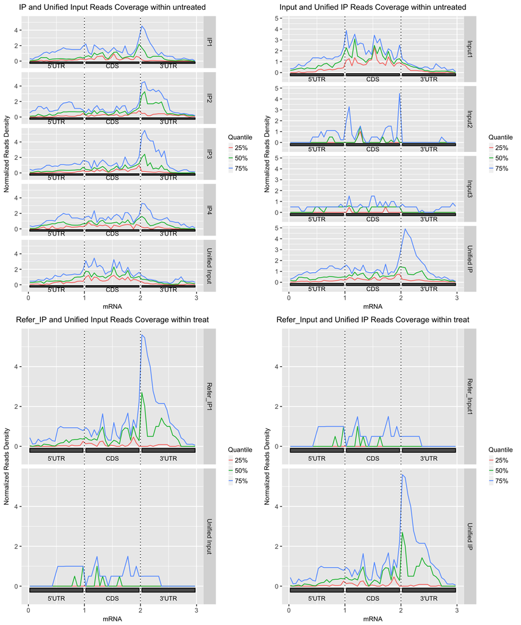

# 4 Quality assessment for the enrichment signal strength

## 4.1 Evaluate enrichment signal strength using ESES method

This module evaluates the enrichment of m6A signal in IP samples and identifies potentially failed immunoprecipitation experiments. **Trumpet** package uses exome signal extraction scaling (ESES) metrics, which is modified based on the signal extraction scaling (SES) approach that previously used in assessing ChIP-seq data signals. ESES metrics can calculate the percent of region enriched with signal and the scale factor showing the strength of signal by comparing the unified Input sample. It can also detect abnormal Input control samples. The assessment result will return figures and a table.

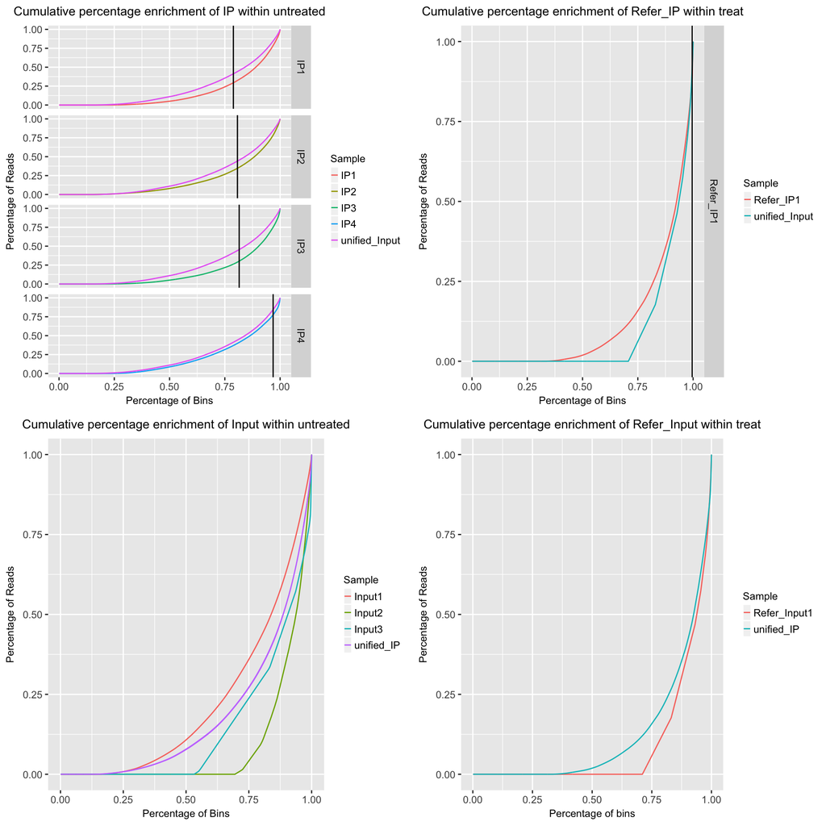

| Sample ID | Percent of Region Enriched with Signal | Scale Factor |
| --- | --- | --- |
| IP1 | 21.14 % | 0.12 |
| IP2 | 19.3 % | 0.1 |
| IP3 | 18.51 % | 0.15 |
| IP4 | 3.16 % | 0.07 |
| Refer_IP1 | 0.42 % | 0.03 |

**Note: The x-axis denotes the percentages of bins with signal reads in the whole transcriptome, and the y-axis denotes the percentages of the normalized cumulative reads count. The black line divides the genome into two regions: the background region and the enrichment signal region. The point at which the distance of the percentage between the IP and Input is maximized shows the strength of enrichment signal in IP samples; the greater the separation between IP and Input at this point, the better the IP enrichment at appropriate sequencing depth, with parameter `Scale Factor` standing for it.**

## 4.2 Assesse the enrichment of m6A signal with C-test

**Trumpet** package also relies on C-test, which was used in the exomePeak package to predict RNA methylation sites. It compares two Poisson means to detect the regions enriched with m6A signal at different levels. The percentage of bins that enriched in the IP sample with m6A signal at different fold enrichment thresholds are counted and plotted. It is then possible to differ between different samples.

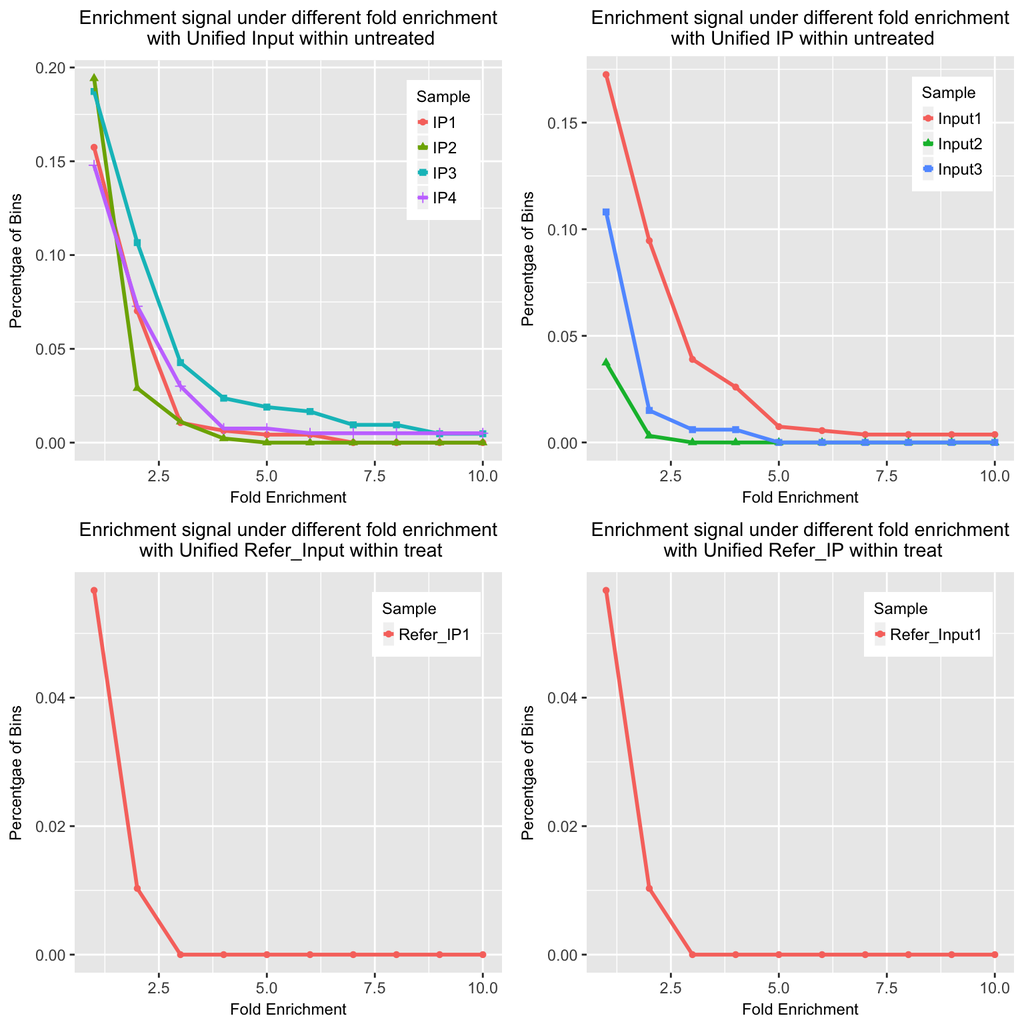

# 5 Comparison between different biological replicates

## 5.1 Hierarchical clustering of samples

Hierarchical Clustering (HC) is applied to all the samples to identify possible outliers and to assess the relative similarity between samples and groups (if applicable).

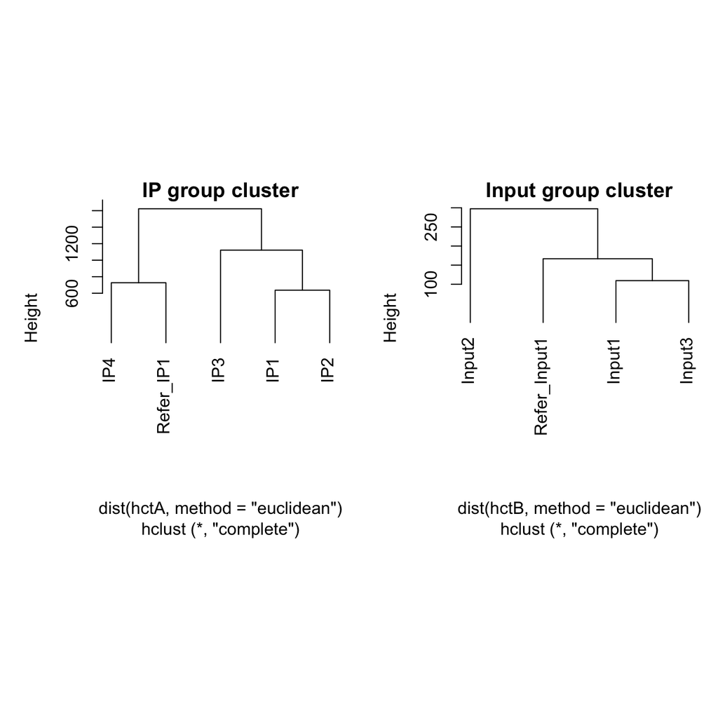

## 5.2 Heterogeneity of reads coverage

Compared with Input sample, the reads coverage is much more uneven in IP samples for the same gene, which may be due to the enrichment signal around the true methylation sites as well as possible bias and artifacts. Thus, the heterogeneity of reads coverage is also assessed in **Trumpet** package with the mean and standard deviation (SD) of reads count in each gene of each sample. We then use local regression to fit a curve based on mean and SD for each gene. The value of mean and SD have been logarithm transformed.

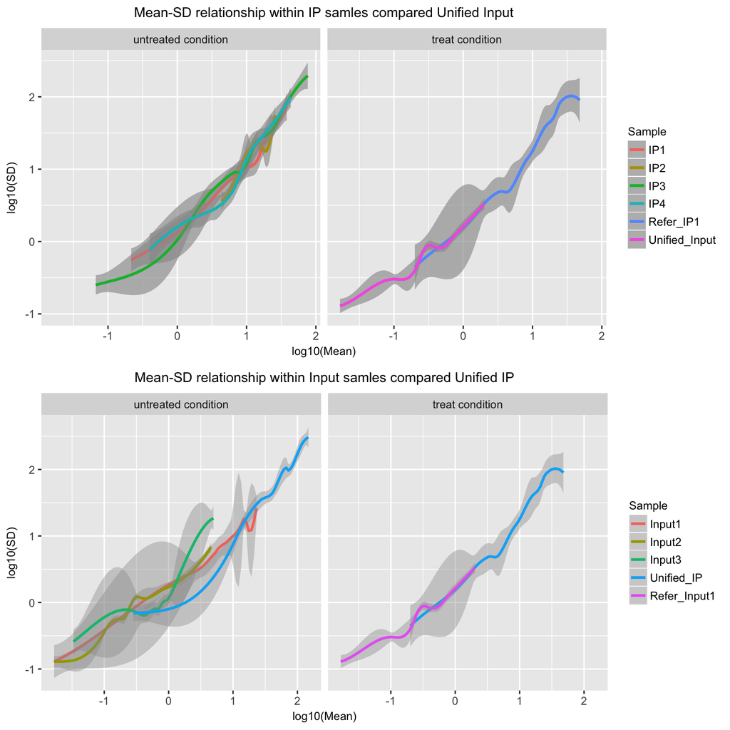

# 6 Sample consistency and reproducibility

This metric is used to assess the degree of difference between multiple biological replicates.Firstly, the reads count should be eliminated the difference in sequencing depth between multiple biological replicates. Conveniently,the reads count can be normalized in this metrics automatically. Assume we have multiple biological replicates obtained from the same experimental condition, the mean and standard deviation of the reads count of the same bin across different samples can be calculated respectively. Then, it is possible to fit the two with a local regression curves to show the consistency between multiple samples, or compare the reproducibility of the samples obtained from different conditions.

```
## [1] "The number of samples in each condition should be larger than three when using this function"
```

# 7 Compare IP samples’ enrichment signal to known data set.

In this part, we compare the strength of immunoprecipitation signal to the known experiment data set. We use the density plot to show the distribution of IP samples’ signal strength including regions enriched with signal, the signal reads count as well as the scale factor. All the three density distribution curves are based on our known experiment data, with the vetical lines in each plot indicating unknown input samples (the data to be evaluated). The following plot will show the result.

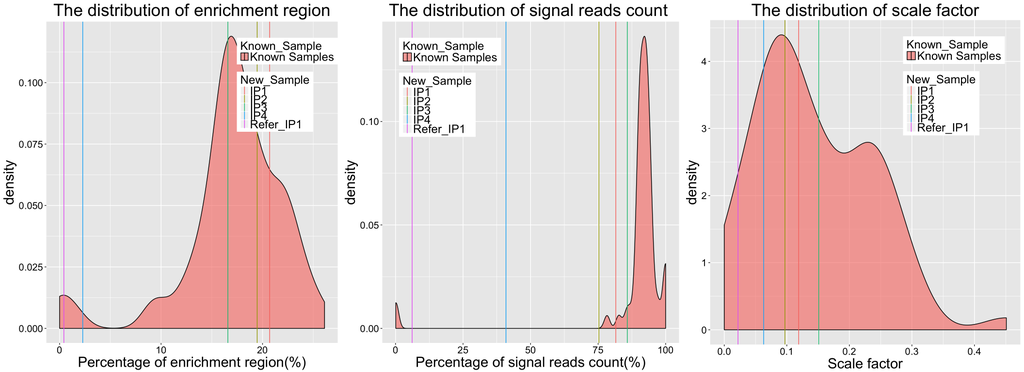